# **Analysising Mortality**

# Introduction

Here, we demostrate how using R we can explore the the mortality of the Palauan population in 2005. We compare this with data from the Cook Islands in 2006. What we aim to do is compute the Crude Death Rates and then use standardisation to compare the two. We also use decomposition to explore the age-group specific role age composition and mortality play in explaining this difference.

# Load Packages

```r
library(tidyverse)
library(ggthemes)
library(gt)
```

# Crude Mortality

Compute CDR for both Palau and the Cook Islands

```r
mortality = read_csv("data/mortality.csv")
```

## Initial Data

Split the data into each island

```r
mortality %>%
  gt() %>%
  tab_style(style = cell_fill(color = "#1F78B4"),
            locations = cells_column_labels(columns = 1:5))
```

| Island | Year | Age | Deaths | Population |
| --- | --- | --- | --- | --- |
| Cook Islands | 2006 | 00 to 04 | 3 | 1509 |
| Cook Islands | 2006 | 05 to 09 | 0 | 1513 |
| Cook Islands | 2006 | 10 to 14 | 1 | 1679 |
| Cook Islands | 2006 | 15 to 19 | 4 | 1450 |
| Cook Islands | 2006 | 20 to 24 | 1 | 1058 |
| Cook Islands | 2006 | 25 to 29 | 0 | 913 |
| Cook Islands | 2006 | 30 to 34 | 0 | 1022 |
| Cook Islands | 2006 | 35 to 39 | 0 | 1083 |
| Cook Islands | 2006 | 40 to 44 | 2 | 1096 |
| Cook Islands | 2006 | 45 to 49 | 0 | 931 |
| Cook Islands | 2006 | 50 to 54 | 4 | 725 |
| Cook Islands | 2006 | 55 to 59 | 10 | 634 |
| Cook Islands | 2006 | 60 to 64 | 6 | 549 |
| Cook Islands | 2006 | 65 to 69 | 5 | 451 |
| Cook Islands | 2006 | 70 to 74 | 19 | 352 |
| Cook Islands | 2006 | 75 plus | 30 | 359 |
| Palau | 2005 | 00 to 04 | 6 | 1363 |
| Palau | 2005 | 05 to 09 | 0 | 1521 |
| Palau | 2005 | 10 to 14 | 0 | 1914 |
| Palau | 2005 | 15 to 19 | 2 | 1462 |
| Palau | 2005 | 20 to 24 | 1 | 1266 |
| Palau | 2005 | 25 to 29 | 5 | 1583 |
| Palau | 2005 | 30 to 34 | 4 | 1856 |
| Palau | 2005 | 35 to 39 | 6 | 1965 |
| Palau | 2005 | 40 to 44 | 9 | 1887 |
| Palau | 2005 | 45 to 49 | 13 | 1534 |
| Palau | 2005 | 50 to 54 | 14 | 1182 |
| Palau | 2005 | 55 to 59 | 9 | 732 |
| Palau | 2005 | 60 to 64 | 10 | 506 |
| Palau | 2005 | 65 to 69 | 8 | 373 |
| Palau | 2005 | 70 to 74 | 11 | 257 |
| Palau | 2005 | 75 plus | 36 | 506 |

After splitting the data calculate age specific death rate for both island nations We do this for each age group in the data.

```r
# split the data to calculate
cook_mortality = mortality %>%
  filter(Island == "Cook Islands")
palau_mortality = mortality %>%
  filter(Island == "Palau")

# find total pop
cook_total = sum(cook_mortality$Population)
palau_total = sum(palau_mortality$Population)

# find age group proporitions for age composition
cook_mortality$Proportion_Age = cook_mortality$Population /
  cook_total

palau_mortality$Proportion_Age = palau_mortality$Population /
  palau_total

# calculate age specific death rate
cook_mortality$Death_Rate = cook_mortality$Deaths /
  cook_mortality$Population

palau_mortality$Death_Rate = palau_mortality$Deaths /
  palau_mortality$Population
```

## Cook Mortality 2006

```r
cook_mortality %>%
  gt() %>%
  tab_style(style = cell_fill(color = "#1F78B4"),
            locations = cells_column_labels(columns = 1:7))
```

| Island | Year | Age | Deaths | Population | Proportion_Age | Death_Rate |
| --- | --- | --- | --- | --- | --- | --- |
| Cook Islands | 2006 | 00 to 04 | 3 | 1509 | 0.09847298 | 0.0019880716 |
| Cook Islands | 2006 | 05 to 09 | 0 | 1513 | 0.09873401 | 0.0000000000 |
| Cook Islands | 2006 | 10 to 14 | 1 | 1679 | 0.10956669 | 0.0005955926 |
| Cook Islands | 2006 | 15 to 19 | 4 | 1450 | 0.09462281 | 0.0027586207 |
| Cook Islands | 2006 | 20 to 24 | 1 | 1058 | 0.06904203 | 0.0009451796 |
| Cook Islands | 2006 | 25 to 29 | 0 | 913 | 0.05957974 | 0.0000000000 |
| Cook Islands | 2006 | 30 to 34 | 0 | 1022 | 0.06669277 | 0.0000000000 |
| Cook Islands | 2006 | 35 to 39 | 0 | 1083 | 0.07067345 | 0.0000000000 |
| Cook Islands | 2006 | 40 to 44 | 2 | 1096 | 0.07152180 | 0.0018248175 |
| Cook Islands | 2006 | 45 to 49 | 0 | 931 | 0.06075437 | 0.0000000000 |
| Cook Islands | 2006 | 50 to 54 | 4 | 725 | 0.04731141 | 0.0055172414 |
| Cook Islands | 2006 | 55 to 59 | 10 | 634 | 0.04137301 | 0.0157728707 |
| Cook Islands | 2006 | 60 to 64 | 6 | 549 | 0.03582616 | 0.0109289617 |
| Cook Islands | 2006 | 65 to 69 | 5 | 451 | 0.02943096 | 0.0110864745 |
| Cook Islands | 2006 | 70 to 74 | 19 | 352 | 0.02297050 | 0.0539772727 |
| Cook Islands | 2006 | 75 plus | 30 | 359 | 0.02342730 | 0.0835654596 |

## Palau Mortality 2005

```r
palau_mortality %>%
  gt() %>%
  tab_style(style = cell_fill(color = "#1F78B4"),
            locations = cells_column_labels(columns = 1:7))
```

| Island | Year | Age | Deaths | Population | Proportion_Age | Death_Rate |
| --- | --- | --- | --- | --- | --- | --- |
| Palau | 2005 | 00 to 04 | 6 | 1363 | 0.06846838 | 0.0044020543 |
| Palau | 2005 | 05 to 09 | 0 | 1521 | 0.07640528 | 0.0000000000 |
| Palau | 2005 | 10 to 14 | 0 | 1914 | 0.09614708 | 0.0000000000 |
| Palau | 2005 | 15 to 19 | 2 | 1462 | 0.07344150 | 0.0013679891 |
| Palau | 2005 | 20 to 24 | 1 | 1266 | 0.06359572 | 0.0007898894 |
| Palau | 2005 | 25 to 29 | 5 | 1583 | 0.07951977 | 0.0031585597 |
| Palau | 2005 | 30 to 34 | 4 | 1856 | 0.09323354 | 0.0021551724 |
| Palau | 2005 | 35 to 39 | 6 | 1965 | 0.09870900 | 0.0030534351 |
| Palau | 2005 | 40 to 44 | 9 | 1887 | 0.09479078 | 0.0047694754 |
| Palau | 2005 | 45 to 49 | 13 | 1534 | 0.07705832 | 0.0084745763 |
| Palau | 2005 | 50 to 54 | 14 | 1182 | 0.05937610 | 0.0118443316 |
| Palau | 2005 | 55 to 59 | 9 | 732 | 0.03677099 | 0.0122950820 |
| Palau | 2005 | 60 to 64 | 10 | 506 | 0.02541819 | 0.0197628458 |
| Palau | 2005 | 65 to 69 | 8 | 373 | 0.01873713 | 0.0214477212 |
| Palau | 2005 | 70 to 74 | 11 | 257 | 0.01291003 | 0.0428015564 |
| Palau | 2005 | 75 plus | 36 | 506 | 0.02541819 | 0.0711462451 |

We now sum up the age death rates into a crude death rate.

```r
cook_cdr = sum(cook_mortality$Deaths) /
  sum(cook_mortality$Population) * 1000

palau_cdr = sum(palau_mortality$Deaths) /
  sum(palau_mortality$Population) * 1000

paste("Cook Islands Crude Death Rate:", round(cook_cdr, 2), "per 1000")
```

```
## [1] "Cook Islands Crude Death Rate: 5.55 per 1000"
```

```r
paste("Palau Crude Death Rate:", round(palau_cdr, 2), "per 1000")
```

```
## [1] "Palau Crude Death Rate: 6.73 per 1000"
```

# Standardisation

Using Standardisation we can compare the death rates in three ways. Seeing how each place would function under the others’ age composition, and seeing how they would function using the mean age composition between the two.

```r
# average age composition
standardisation = data.frame(
  Age = cook_mortality$Age,
  Age_Dist_Cook = cook_mortality$Proportion_Age, # age composition cook
  Age_Dist_Palau = palau_mortality$Proportion_Age, # age compoistion # palau
  Death_Rate_Cook = cook_mortality$Death_Rate,
  Death_Rate_Palau = palau_mortality$Death_Rate
)

# calculated average age distribution per row
standardisation$Age_Dist_Average = (standardisation$Age_Dist_Cook +
  standardisation$Age_Dist_Palau) / 2

# calculate death rate standard average dist for palau and cook islands
standardisation$Death_Rate_Cook_Average_Age = standardisation$Death_Rate_Cook *
  standardisation$Age_Dist_Average

standardisation$Death_Rate_Palau_Average_Age = standardisation$Death_Rate_Palau *
  standardisation$Age_Dist_Average

# calculate cross standards
standardisation$Death_Rate_Cook_Palau_Age = standardisation$Death_Rate_Cook *
  standardisation$Age_Dist_Palau

standardisation$Death_Rate_Palau_Cook_Age = standardisation$Death_Rate_Palau *
  standardisation$Age_Dist_Cook

standardisation %>%
  gt() %>%
  tab_style(style = cell_fill(color = "#1F78B4"),
            locations = cells_column_labels(columns = 1:10))
```

| Age | Age_Dist_Cook | Age_Dist_Palau | Death_Rate_Cook | Death_Rate_Palau | Age_Dist_Average | Death_Rate_Cook_Average_Age | Death_Rate_Palau_Average_Age | Death_Rate_Cook_Palau_Age | Death_Rate_Palau_Cook_Age |
| --- | --- | --- | --- | --- | --- | --- | --- | --- | --- |
| 00 to 04 | 0.09847298 | 0.06846838 | 0.0019880716 | 0.0044020543 | 0.08347068 | 1.659457e-04 | 3.674425e-04 | 1.361200e-04 | 4.334834e-04 |
| 05 to 09 | 0.09873401 | 0.07640528 | 0.0000000000 | 0.0000000000 | 0.08756965 | 0.000000e+00 | 0.000000e+00 | 0.000000e+00 | 0.000000e+00 |
| 10 to 14 | 0.10956669 | 0.09614708 | 0.0005955926 | 0.0000000000 | 0.10285689 | 6.126080e-05 | 0.000000e+00 | 5.726449e-05 | 0.000000e+00 |
| 15 to 19 | 0.09462281 | 0.07344150 | 0.0027586207 | 0.0013679891 | 0.08403216 | 2.318129e-04 | 1.149551e-04 | 2.025972e-04 | 1.294430e-04 |
| 20 to 24 | 0.06904203 | 0.06359572 | 0.0009451796 | 0.0007898894 | 0.06631887 | 6.268324e-05 | 5.238458e-05 | 6.010938e-05 | 5.453557e-05 |
| 25 to 29 | 0.05957974 | 0.07951977 | 0.0000000000 | 0.0031585597 | 0.06954976 | 0.000000e+00 | 2.196771e-04 | 0.000000e+00 | 1.881862e-04 |
| 30 to 34 | 0.06669277 | 0.09323354 | 0.0000000000 | 0.0021551724 | 0.07996315 | 0.000000e+00 | 1.723344e-04 | 0.000000e+00 | 1.437344e-04 |
| 35 to 39 | 0.07067345 | 0.09870900 | 0.0000000000 | 0.0030534351 | 0.08469123 | 0.000000e+00 | 2.585992e-04 | 0.000000e+00 | 2.157968e-04 |
| 40 to 44 | 0.07152180 | 0.09479078 | 0.0018248175 | 0.0047694754 | 0.08315629 | 1.517450e-04 | 3.966119e-04 | 1.729759e-04 | 3.411214e-04 |
| 45 to 49 | 0.06075437 | 0.07705832 | 0.0000000000 | 0.0084745763 | 0.06890635 | 0.000000e+00 | 5.839521e-04 | 0.000000e+00 | 5.148676e-04 |
| 50 to 54 | 0.04731141 | 0.05937610 | 0.0055172414 | 0.0118443316 | 0.05334375 | 2.943104e-04 | 6.318211e-04 | 3.275923e-04 | 5.603720e-04 |
| 55 to 59 | 0.04137301 | 0.03677099 | 0.0157728707 | 0.0122950820 | 0.03907200 | 6.162776e-04 | 4.803934e-04 | 5.799840e-04 | 5.086845e-04 |
| 60 to 64 | 0.03582616 | 0.02541819 | 0.0109289617 | 0.0197628458 | 0.03062217 | 3.346686e-04 | 6.051813e-04 | 2.777945e-04 | 7.080268e-04 |
| 65 to 69 | 0.02943096 | 0.01873713 | 0.0110864745 | 0.0214477212 | 0.02408404 | 2.670071e-04 | 5.165478e-04 | 2.077287e-04 | 6.312270e-04 |
| 70 to 74 | 0.02297050 | 0.01291003 | 0.0539772727 | 0.0428015564 | 0.01794027 | 9.683667e-04 | 7.678714e-04 | 6.968483e-04 | 9.831733e-04 |
| 75 plus | 0.02342730 | 0.02541819 | 0.0835654596 | 0.0711462451 | 0.02442275 | 2.040898e-03 | 1.737587e-03 | 2.124083e-03 | 1.666765e-03 |

```r
# output standardised crudes
standard_cook_cdr_average = sum(standardisation$Death_Rate_Cook_Average_Age) *
  1000
standard_palau_cdr_average = sum(standardisation$Death_Rate_Palau_Average_Age) *
  1000
standard_cook_cdr_palau = sum(standardisation$Death_Rate_Cook_Palau_Age) *
  1000
standard_palau_cdr_cook = sum(standardisation$Death_Rate_Palau_Cook_Age) *
  1000
```

[output not shown]

[output not shown]

[output not shown]

[output not shown]

# Comparison Table

We can output this into a nice lil’ table

```r
comparison_table = data.frame(
  Death_Rate_Method = c("Crude Death Rate per 1000",
                        "Standardised on Average Age Distribution per 1000",
                        "Standardised on Cook Islands Age Distribution per 1000",
                        "Standardised on Palau Age Distribution per 1000"),
  Palau_2005 = c(round(palau_cdr, 2),
                 round(standard_palau_cdr_average, 2),
                 round(standard_palau_cdr_cook, 2),
                 round(palau_cdr, 2)),
  Cook_Islands_2006 = c(round(cook_cdr, 2),
                        round(standard_cook_cdr_average, 2),
                        round(cook_cdr, 2),
                        round(standard_cook_cdr_palau, 2))
)

comparison_table$Difference = comparison_table$Palau_2005 -
  comparison_table$Cook_Islands_2006
```

## Standardisation Results

```r
comparison_table %>%
  gt() %>%
  tab_style(style = cell_fill(color = "#1F78B4"),
            locations = cells_column_labels(columns = 1:4))
```

| Death_Rate_Method | Palau_2005 | Cook_Islands_2006 | Difference |
| --- | --- | --- | --- |
| Crude Death Rate per 1000 | 6.73 | 5.55 | 1.18 |
| Standardised on Average Age Distribution per 1000 | 6.91 | 5.19 | 1.72 |
| Standardised on Cook Islands Age Distribution per 1000 | 7.08 | 5.55 | 1.53 |
| Standardised on Palau Age Distribution per 1000 | 6.73 | 4.84 | 1.89 |

# Decomposition

We can also use decomposition techniques to explore the role of age composition and death rates on this difference between the Cook Islands and Palau.

```r
# set up decomposition dataframe
decomposition = standardisation = data.frame(
  Age = cook_mortality$Age,
  Age_Dist_Palau = palau_mortality$Proportion_Age,
  Age_Dist_Cook = cook_mortality$Proportion_Age,
  Death_Rate_Palau = palau_mortality$Death_Rate,
  Death_Rate_Cook = cook_mortality$Death_Rate
)

# kitagawa decomposition to determine contribution from age dist
decomposition$Contribution_Age_Dist = (decomposition$Age_Dist_Palau -
  decomposition$Age_Dist_Cook) *
  ((decomposition$Death_Rate_Palau +
      decomposition$Death_Rate_Cook) / 2)

# kitagawa decomposition to determine contribution from death rates
decomposition$Contribution_Death_Rate = (decomposition$Death_Rate_Palau -
  decomposition$Death_Rate_Cook) *
  ((decomposition$Age_Dist_Palau +
      decomposition$Age_Dist_Cook) / 2)

# contribution sum
contribution_age = sum(decomposition$Contribution_Age_Dist)
contribution_death = sum(decomposition$Contribution_Death_Rate)
difference = contribution_age + contribution_death
proportion_age = contribution_age / difference
proportion_death = contribution_death / difference
```

## Decomposition Results

```r
# output table
decomposition %>%
  gt() %>%
  tab_style(style = cell_fill(color = "#1F78B4"),
            locations = cells_column_labels(columns = 1:7))
```

| Age | Age_Dist_Palau | Age_Dist_Cook | Death_Rate_Palau | Death_Rate_Cook | Contribution_Age_Dist | Contribution_Death_Rate |
| --- | --- | --- | --- | --- | --- | --- |
| 00 to 04 | 0.06846838 | 0.09847298 | 0.0044020543 | 0.0019880716 | -9.586660e-05 | 2.014968e-04 |
| 05 to 09 | 0.07640528 | 0.09873401 | 0.0000000000 | 0.0000000000 | 0.000000e+00 | 0.000000e+00 |
| 10 to 14 | 0.09614708 | 0.10956669 | 0.0000000000 | 0.0005955926 | -3.996310e-06 | -6.126080e-05 |
| 15 to 19 | 0.07344150 | 0.09462281 | 0.0013679891 | 0.0027586207 | -4.370350e-05 | -1.168578e-04 |
| 20 to 24 | 0.06359572 | 0.06904203 | 0.0007898894 | 0.0009451796 | -4.724858e-06 | -1.029867e-05 |
| 25 to 29 | 0.07951977 | 0.05957974 | 0.0031585597 | 0.0000000000 | 3.149088e-05 | 2.196771e-04 |
| 30 to 34 | 0.09323354 | 0.06669277 | 0.0021551724 | 0.0000000000 | 2.859996e-05 | 1.723344e-04 |
| 35 to 39 | 0.09870900 | 0.07067345 | 0.0030534351 | 0.0000000000 | 4.280236e-05 | 2.585992e-04 |
| 40 to 44 | 0.09479078 | 0.07152180 | 0.0047694754 | 0.0018248175 | 7.672124e-05 | 2.448668e-04 |
| 45 to 49 | 0.07705832 | 0.06075437 | 0.0084745763 | 0.0000000000 | 6.908453e-05 | 5.839521e-04 |
| 50 to 54 | 0.05937610 | 0.04731141 | 0.0118443316 | 0.0055172414 | 1.047310e-04 | 3.375107e-04 |
| 55 to 59 | 0.03677099 | 0.04137301 | 0.0122950820 | 0.0157728707 | -6.458470e-05 | -1.358842e-04 |
| 60 to 64 | 0.02541819 | 0.03582616 | 0.0197628458 | 0.0109289617 | -1.597196e-04 | 2.705127e-04 |
| 65 to 69 | 0.01873713 | 0.02943096 | 0.0214477212 | 0.0110864745 | -1.739576e-04 | 2.495407e-04 |
| 70 to 74 | 0.01291003 | 0.02297050 | 0.0428015564 | 0.0539772727 | -4.868204e-04 | -2.004953e-04 |
| 75 plus | 0.02541819 | 0.02342730 | 0.0711462451 | 0.0835654596 | 1.540071e-04 | -3.033114e-04 |

```r
# output contributions
paste("Difference in Crude Death Rate:",
      round(difference * 1000, 2))
```

```
## [1] "Difference in Crude Death Rate: 1.18"
```

```r
paste("Contribution of Differences in Age Composition:",
      round(contribution_age * 1000, 2))
```

```
## [1] "Contribution of Differences in Age Composition: -0.53"
```

```r
paste("Contribution of Differences in Death Rates:",
      round(contribution_death * 1000, 2))
```

```
## [1] "Contribution of Differences in Death Rates: 1.71"
```

```r
paste("Share of Contribution of Differences in Age Composition:",
      round(proportion_age * 100, 2),"%")
```

```
## [1] "Share of Contribution of Differences in Age Composition: -44.4 %"
```

```r
paste("Share of Contribution of Differences in Death Rates:",
      round(proportion_death * 100, 2),"%")
```

```
## [1] "Share of Contribution of Differences in Death Rates: 144.4 %"
```

# Stacked Bar Chart

Lets visualise this on a stacked bar graph.

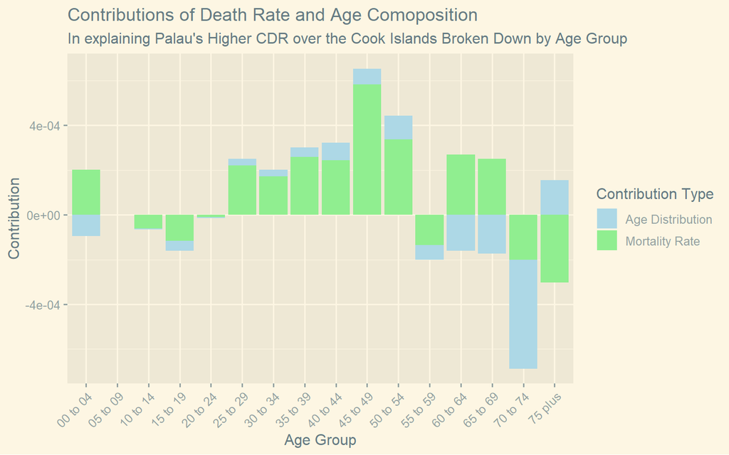

```r
# make into long toplot data
decomp_long = decomposition %>%
  pivot_longer(cols = starts_with("Contribution"),
               names_to = "Contribution_Type", values_to = "Value") %>%
  mutate(Contribution_Type = factor(Contribution_Type,
                                    levels = c("Contribution_Age_Dist",
                                               "Contribution_Death_Rate")))
# give string names
decomp_long$Contribution_Type = ifelse(decomp_long$Contribution_Type == "Contribution_Age_Dist",
                                       "Age Distribution",
                                       "Mortality Rate")

p = ggplot(decomp_long, aes(x = Age, y = Value, fill = Contribution_Type)) +
  geom_bar(stat = "identity", position = "stack") +
  scale_fill_manual(values = c("Age Distribution" = "lightblue",
                               "Mortality Rate" = "lightgreen")) +
  labs(x = "Age Group",
       y = "Contribution",
       title = "Contributions of Death Rate and Age Comoposition ",
       subtitle = "In explaining Palau's Higher CDR over the Cook Islands Broken Down by Age Group",
       fill = "Contribution Type") +
  theme_solarized_2() +
  theme(axis.text.x = element_text(angle = 45, hjust = 1))
p
```

```r
ggsave("stacked_bar.png", p)
```